# Introduction to RMarkdown

Data Science for Biologists, Spring 2020

Stephanie J. Spielman

## Introduction to RMarkdown

This is an **RMarkdown** document. R is a computer language, and markdown is a simple formatting syntax, known as a “markup language” (groan puns groan, buckle up), for authoring HTML, PDF, and MS Word documents within plain-text environments. **RMarkdown is a unified framework for integrating markdown formatted-text with R code. It is the best.**

RMarkdown documents begin with a section known as *YAML front matter* (“YAML” = “YAML ain’t markup language”. This is known as recursive acronym. Welcome to the wide world of “Programmers Attempt Naming Humor.”). The front matter, whose contents are bounded by three dashes `---` before and after, specifies document settings including information for how the document should be *rendered* into its final product, as well as any other parameters that are used throughout the RMarkdown file.

As indicated in the YAML front matter, this document will produce an HTML file when you click the **Knit** button (a package called `knitr` will show up and created your beautiful HTML). The *syntax* (code coloring) will be highlighted according to the “tango” scheme (we’ll come back to this later!).

## Resources

Your resources for working with RMarkdown include:

1. [RStudio Rmarkdown documentation](http://rmarkdown.rstudio.com)
2. [RMarkdown Cheatsheet](https://rstudio.com/wp-content/uploads/2015/02/rmarkdown-cheatsheet.pdf)
3. [The definitive RMarkdown reference](https://bookdown.org/yihui/rmarkdown/) by the inventor of RMarkdown, Yihui Xie, a very badass RStudio Engineer who also gives hilarious talks. This book is *incredibly comprehensive*, beware.
   - [Here is](https://yihui.org/en/2018/03/blogdown-video-rstudio-conf/) a talk he gave last year on a new R package `bookdown`, which uses RMarkdown to make E-books and more (as in, every single online book in this class was made using `bookdown`).

## Briefly, markdown syntax

Below are LIMITED examples of writing markdown documents. For a comprehensive set of ways to customize your documents, see [the official basic syntax](https://rmarkdown.rstudio.com/authoring_basics.html)

We can write headers of varying size with different numbers of hashtags (remember, this is NOT R code - these are not comments!).

# Biggest header

## Slightly smaller

### And smaller

#### And smaller!!!

##### so smol

###### this is the smolest

We can also make bulleted lists, as shown below. There always needs to be a new line before the start of a list, otherwise it will NOT render properly. (See this for yourself by deleting the next new line and knitting. No more bullets :( )

- **bold text** and **bold text**
- *italics text* and *italics text*
- `code formatted text`, but this is NOT actual code!!
  - A nested list item is tabbed in
- We can also use stars for bullets
- And dashes too

> This is known as a blockquote. It’s sometimes useful.

Any HTML component will also work in a markdown document. If you know HTML, style it up as you wish. If you don’t know HTML, you’re probably a happier person.

One important HTML bit to know, however, are comments. *HTML comments* are which are enclosed with `<!--` and `-->`. When you click **Knit**, the engine will ignore these bits - they are comments! Regular R-style comments won’t work in markdown - in markdown, R comments are headers.

## Working with code chunks

Below is an *R code chunk*, which RStudio has kindly shaded in grey for easier visibility.

```r
## This is a code chunk.
head(iris)
```

```
##   Sepal.Length Sepal.Width Petal.Length Petal.Width Species
## 1          5.1         3.5          1.4         0.2  setosa
## 2          4.9         3.0          1.4         0.2  setosa
## 3          4.7         3.2          1.3         0.2  setosa
## 4          4.6         3.1          1.5         0.2  setosa
## 5          5.0         3.6          1.4         0.2  setosa
## 6          5.4         3.9          1.7         0.4  setosa
```

There are several ways you can modify the behavior of code chunks, by adding arguments inside the `{r}` part at the beginning.

0. The `{r}` itself means “This is R code.” It is possible, in fact, to specify *other languages(!)* rather than R, for example you can run bash code within RMarkdown documents by writing `{bash}` instead. **This is beyond the scope of our class.** We will only be writing R code here!
1. You can name a chunk by adding a name like `{r, code-chunk-name}`.
2. There are several parameters which you can include that modify how the `knitr` engine deals with the code chunk, some of which are described below. Each parameter should be set to either `TRUE` or `FALSE`. These defaults are implicitly applied if you don’t specify:
   - `include=TRUE`: Should this code chunk itself be **included** in the final output. `include=FALSE` means the code will still be run but the knitted document will NOT show the code or its output.
   - `echo=TRUE`: Should the **output** from the code be displayed in the knitted document?
   - `eval=TRUE`: Should we even run this code chunk? If `FALSE`, the code chunk will appear as code but it won’t have been run, so it also won’t have any output.
   - `warnings=TRUE`: If the code produces any warning messages, should they be displayed in the knitted document?
   - `messages=TRUE`: If the code produces any general messages, should they be displayed in the knitted document?
   - `error=FALSE`: If the code is broken and gives errors, the default behavior (`FALSE`) is to halt knitting entirely until the user fixes the bug. To allow knitting to proceed and show the error message, set `error=TRUE`
   - `collapse=FALSE`: If `FALSE`, the code output will be displayed in a separate white box from the code itself. If `TRUE`, output will be embedded into the code itself.

#### EXERCISE SET ONE

Practice writing code chunks in the space below. After you write each chunk, make sure it works as expected by pressing the **green arrow** at the top-right corner of the chunk. This will **Run** your code chunk and reveal its output in place, without going through the hassle of knitting the entire document. You can clear this output by clicking the “x” in its top right corner. You are also welcome to Knit each time if that works for you!

> Beware: Pressing the green arrow doesn’t always mean the code was run in the Console. If/when you encouter errors that suggest the code you thought you ran didn’t run, it’s because the code was run..elsewhere.
1. Write a code chunk named “chunk-1” that reveals the *last six rows* (hint: use the function `tail()`) of the `iris` data frame.

```r
tail(iris)
```

```
##     Sepal.Length Sepal.Width Petal.Length Petal.Width   Species
## 145          6.7         3.3          5.7         2.5 virginica
## 146          6.7         3.0          5.2         2.3 virginica
## 147          6.3         2.5          5.0         1.9 virginica
## 148          6.5         3.0          5.2         2.0 virginica
## 149          6.2         3.4          5.4         2.3 virginica
## 150          5.9         3.0          5.1         1.8 virginica
```

2. Write a code chunk named “chunk-2” that calculates the maximum value of iris sepal lengths (hint: remember the function `max()` and the `$` for working with columns). In your chunk, set the option `collapse=TRUE` to see how output looks different.

```r
max(iris$Sepal.Length)
## [1] 7.9
```

3. Write a code chunk named “chunk-3” that makes a *histogram* of iris petal widths. Be sure to style your plot appropriately with clean labels. Execute this code chunk with and without the added parameter `messages=FALSE`. What difference do you see?

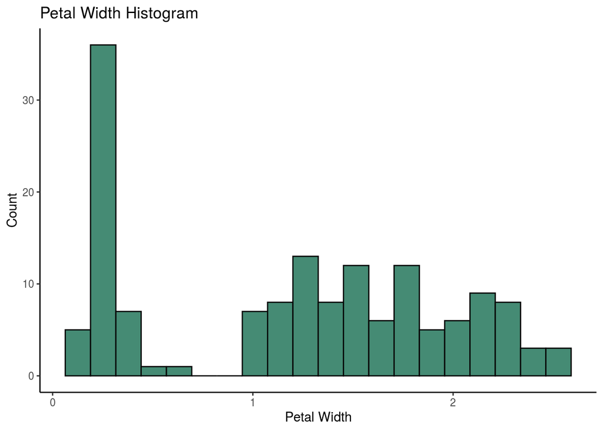

```r
library(ggplot2)
ggplot(iris, aes(x = Petal.Width)) +
  geom_histogram(fill = "aquamarine4",
                 color = "grey3" ,
                 bins = 20) +
  theme_classic() +
  labs(x = "Petal Width" , y = "Count", title = "Petal Width Histogram")
```

4. Write a code chunk named “chunk-4” that makes a *scatterplot* of iris petal widths across petal lengths, where points are colored according their sepal widths. Be sure to style your plot appropriately with clean labels.

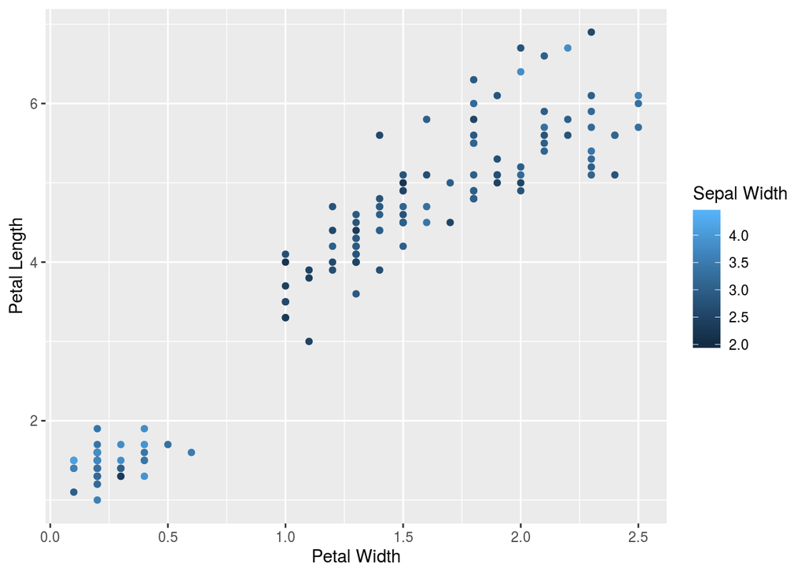

   ```r
   library(ggplot2)
   ggplot(iris, aes(x = Petal.Width, y = Petal.Length)) +
     geom_point(aes(color = Sepal.Width)) +
     labs(x = "Petal Width", y = "Petal Length", color = "Sepal Width")
   ```

**At this point, if you haven’t already, Knit the whole document to see how your chunks appear!**

## Working with global options

#### EXERCISE SET TWO

Modify the YAML frontmatter and the R `setup` chunk to customize this document as your own. The `setup` chunk is a standard part of RMarkdown documents used to set **global options** (i.e., applies to whole document) and values used throughout the entire document.

**After each step, KNIT the document to confirm it worked.**

**Again, after each step, KNIT the document to confirm it worked.**

### Brewer Palettes

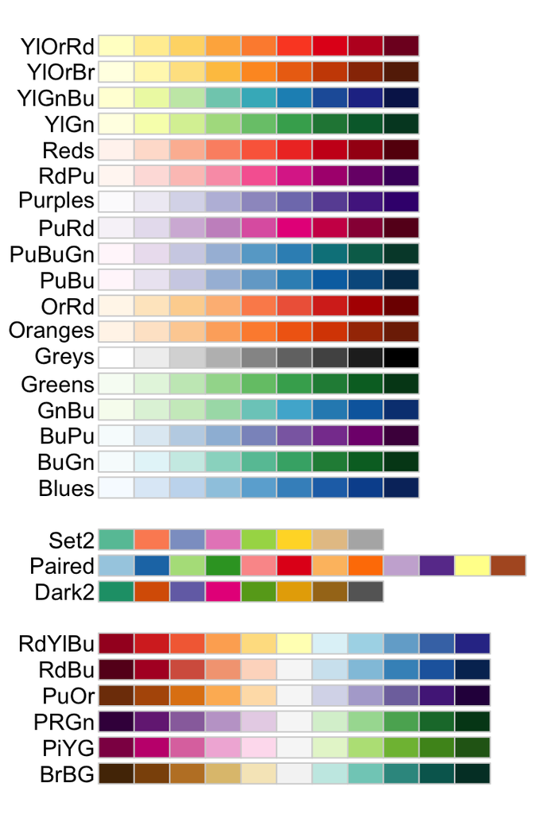

Colorblind-friendly Brewer Palettes